# Analyzing multimodal PBMC1K data (RNA+ADT) with Seurat

# Introduction

Matrix and Analysis Metadata Standards (MAMS) can be used to capture the relevant information about the data matrices and annotations that are produced during common and complex analysis workflows for single-cell data. This use case demonstrates how MAMS can be used to annotate matrices and annotations that are produced during the analysis of multi-modal single-cell data containing both RNA and Antibody Derived Tags (ADTs). We will analyze the [PBMC 1K dataset](https://support.10xgenomics.com/single-cell-gene-expression/datasets/4.0.0/SC3_v3_NextGem_SI_PBMC_CSP_1K) with the Seurat package according to the [Multi-modal](https://satijalab.org/seurat/articles/multimodal_vignette.html) and [Weighted Nearst Neighbor vignettes](https://satijalab.org/seurat/articles/weighted_nearest_neighbor_analysis.html). The analytical steps include:

1. Importing the raw/droplet and filtered/cell matrices
2. Performing quality control and further subsetting the filtered matrix to only include high-quality cells
3. Clustering all cells with RNA only
4. Clustering all cells with ADTs only
5. Clustering all cells with both RNA and ADT
6. Clustering T-cells with RNA only
7. Clustering T-cells with ADT only
8. Clustering T-cells with both RNA and ADT

This workflow demonstrates how different subsets of cells/observations are produced due to QC/filtering or can be made based on different biological subsets. It also produces several matrices and annotations from different modalities. Note that the goal of this workflow is less about producing the best clustering results and cell type characterization. Rather it is focused on producing data/results that is commonly generated during real-world analyses which can be annotated with MAMS. For more information about MAMS, see the [GitHub repository](https://github.com/single-cell-mams/mams)

# Importing

```r
library(dplyr)
library(Seurat)
library(patchwork)
```

First, we will import raw/droplet and filtered/cell matrices:

```r
raw.matrices <- Read10X(data.dir = "../../data/raw_feature_bc_matrix")
```

```
## 10X data contains more than one type and is being returned as a list containing matrices of each type.
```

```r
data.raw <- CreateSeuratObject(counts = raw.matrices[[1]], assay = "RNA", project = "pbmc1k")
adt <- CreateAssayObject(counts = raw.matrices[[2]])
data.raw[["ADT"]] <- adt

nonempty.matrices <- Read10X(data.dir = "../../data/filtered_feature_bc_matrix")
```

```
## 10X data contains more than one type and is being returned as a list containing matrices of each type.
```

```r
data.nonempty <- CreateSeuratObject(counts = nonempty.matrices[[1]], assay = "RNA", project = "pbmc1k")
adt <- CreateAssayObject(counts = nonempty.matrices[[2]])
data.nonempty[["ADT"]] <- adt
```

# Quality control

The filtered matrix will be further subsetted based on mitochondrial percentage and total number of features detected:

```r
data.nonempty[["percent.mt"]] <- PercentageFeatureSet(data.nonempty, pattern = "^MT-")
data <- subset(data.nonempty, subset = nFeature_RNA > 200 & percent.mt < 5)
```

# Clustering

The goal of many single cell workflows are to perform clustering to identify biologically distrinct groups of cells. We will perform clustering on all QC’ed cells using RNA, ADT, or both and then also re-cluster the T-cells by themselves.

## Analyzing all cells

### RNA only clustering of all cells

```r
DefaultAssay(data) <- 'RNA'
data <- NormalizeData(data) %>% FindVariableFeatures() %>% ScaleData() %>% RunPCA()
```

```
## PC_ 1
## Positive:  RPS18, MALAT1, TRAC, LTB, IL7R, IL32, TRBC2, CD27, PRKCQ-AS1, CD69
##     B2M, TRBC1, LIME1, ISG20, ARL4C, ITM2A, SRSF7, DNAJB1, MYC, JUNB
##     C20orf204, NELL2, LRRN3, FAM153CP, BCL2, TSHZ2, RPLP1, AQP3, ASH1L, CD52
## Negative:  KLF4, CST3, LYZ, TYROBP, MPEG1, ZNF385A, CD68, MNDA, FCER1G, IFI30
##     FPR1, FCN1, TNFAIP2, SERPINA1, S100A9, S100A8, GRN, PLBD1, VCAN, S100A12
##     NCF2, LST1, CSTA, MS4A6A, CD302, CPVL, SPI1, CSF3R, SYK, CLEC7A
## PC_ 2
## Positive:  S100A12, FPR1, S100A9, FCN1, VCAN, PLBD1, RBP7, TNFAIP2, CSTA, SERPINA1
##     QPCT, MNDA, SLC7A7, CD14, ASGR1, MARCKS, CDA, CEBPA, S100A8, SLC11A1
##     CRISPLD2, JUNB, LILRB2, HOMER3, RAB3D, MGST1, BST1, ALDH1A1, CD93, IRAK3
## Negative:  MYO1E, BLNK, PLD4, TUBB6, LILRA4, TCF4, IL3RA, MYBL2, IRF8, DERL3
##     CCDC50, COBLL1, PPP1R14A, SERPINF1, BCL11A, LRRC26, NLRP7, LAMA5, TSPAN13, WDFY4
##     CUEDC1, LILRB4, PTK7, SCAMP5, AC097375.1, SCT, TPM2, GZMB, NIBAN3, ST14
## PC_ 3
## Positive:  RPS18, MALAT1, TMSB10, RPLP1, FOS, JUNB, VIM, GABARAP, CCDC50, PPIA
##     GAPT, HNRNPU, SLC25A3, LTB, MIF, MS4A6A, CD52, FOSB, JUN, SHTN1
##     TGFBI, NME2, CD302, CD68, RNASE6, HLA-DMA, NPC2, SH2B3, ARSB, S100A6
## Negative:  RAB27B, LMNA, GTPBP2, DMTN, CDKN1A, PDLIM1, AL117336.2, CD151, EVA1B, CTNNA1
##     F2R, MIR4435-2HG, FNTB, ARHGAP18, CD9, LRP12, HECW2-AS1, MAP3K7CL, TST, MCTP1
##     STOM, NEXN, GSN, TSC22D1, TNFSF4, MMD, ITGA2B, PBX1, TCEAL9, GP1BB
## PC_ 4
## Positive:  BANK1, MS4A1, IGHD, CD22, POU2AF1, CD79A, FCRL2, MEF2C, FCER2, TCL1A
##     IGHM, FAM30A, MARCH1, ADAM28, HLA-DMB, LINC00926, NIBAN3, CYBB, RALGPS2, PAX5
##     ZFP14, CD24, IGKC, CD79B, SLC6A16, FCRLA, BCL11A, LYN, BTK, HLA-DOB
## Negative:  B2M, S100A4, CST7, PFN1, MIAT, GZMA, IL32, ITGB1, S100A10, MYO1F
##     CRIP1, KLRB1, FCGR3A, KLRG1, ACTG1, NKG7, FLNA, RHOC, VIM, CFL1
##     S100A11, PREX1, ARPC2, AHNAK, FUT7, NFKBIA, NPDC1, S100A6, JAKMIP1, IFITM2
## PC_ 5
## Positive:  HLA-DQA1, HLA-DQB1, ABCB4, CD22, HLA-DOB, HLA-DRB5, MS4A1, HLA-DQB2, IL13RA1, HLA-DPB1
##     POU2AF1, IGHD, HLA-DQA2, NAV1, AC064805.1, CIITA, BANK1, AC092809.2, CD79A, HLA-DRB1
##     FCER2, CLIC2, FCRL2, IRF5, HLA-DPA1, ADAM28, ASB2, SCIMP, HLA-DRA, GNGT2
## Negative:  DMXL2, CUEDC1, TPM2, COBLL1, LRRC26, NLRP7, LAMA5, TSPAN13, GAPT, SCT
##     SCAMP5, AC097375.1, SCARA5, RNF144B, CD302, SLC35F3, MYBL2, AC069277.1, PLXNA4, CLCN5
##     DERL3, SERPINF1, PLEKHD1, MAP1A, SMPD3, GZMB, RBP7, CD36, SLC15A4, TGFBI
```

```r
data <- FindNeighbors(data, dims = 1:10)
data <- FindClusters(data, resolution = 2, verbose = FALSE)
data <- RunUMAP(data, reduction = 'pca', dims = 1:10, assay = 'RNA',
              reduction.name = 'rna.umap', reduction.key = 'rnaUMAP_')
```

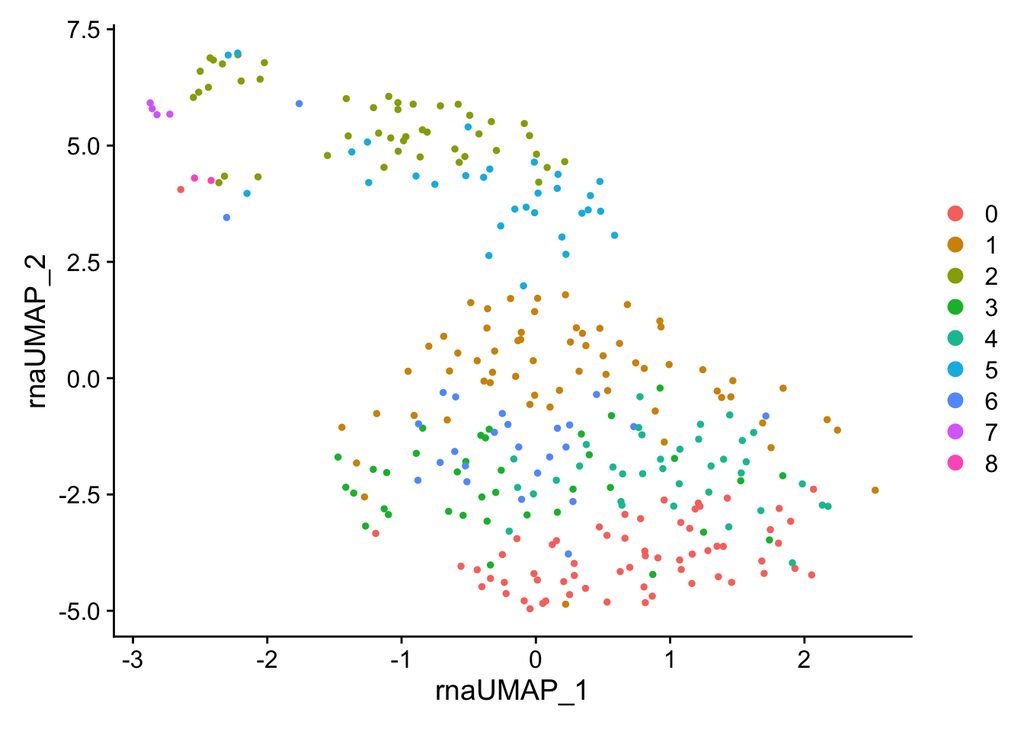

```r
DimPlot(data, reduction = 'rna.umap')
```

### ADT only clustering of all cells

```r
DefaultAssay(data) <- 'ADT'
VariableFeatures(data) <- rownames(data[["ADT"]])
data <- NormalizeData(data, normalization.method = 'CLR', margin = 2) %>%
  ScaleData() %>% RunPCA(reduction.name = 'apca', dims = 1:10)
```

```
## Normalizing across cells
```

```
## PC_ 1
## Positive:  CD14.1, CD15, CD56, CD16, IgG1, TIGIT.1, CD25, IgG2a, CD8a, CD19.1
##     PD-1, IgG2b
## Negative:  CD3, CD127, CD4.1, CD45RA, CD34.1, CD28.1, CD274.1, CD20, CD86.1, CD62L
##     CD80.1, CD11b
## PC_ 2
## Positive:  CD45RO, CD25, CD4.1, PD-1, TIGIT.1, CD127, CD3, CD62L, CD14.1, CD80.1
##     IgG1, CD86.1
## Negative:  CD45RA, CD34.1, CD8a, CD56, CD19.1, CD16, CD274.1, CD20, IgG2a, CD15
##     IgG2b, CD28.1
## PC_ 3
## Positive:  IgG1, CD4.1, CD15, CD19.1, CD14.1, IgG2a, IgG2b, CD20, CD45RA, CD28.1
##     CD11b, CD62L
## Negative:  CD8a, TIGIT.1, CD16, CD56, CD45RO, PD-1, CD34.1, CD3, CD80.1, CD25
##     CD86.1, CD274.1
## PC_ 4
## Positive:  CD19.1, CD25, CD34.1, CD86.1, CD45RO, CD62L, CD8a, CD80.1, IgG1, CD11b
##     CD14.1, CD20
## Negative:  CD274.1, CD56, CD15, CD3, CD28.1, CD16, CD4.1, IgG2a, CD127, IgG2b
##     PD-1, TIGIT.1
## PC_ 5
## Positive:  CD56, CD20, CD4.1, CD16, TIGIT.1, CD19.1, CD45RA, CD25, IgG2a, CD86.1
##     CD80.1, PD-1
## Negative:  CD8a, IgG2b, CD127, CD14.1, CD28.1, CD3, CD45RO, CD15, IgG1, CD11b
##     CD34.1, CD62L
```

```r
data <- FindNeighbors(data, reduction = "apca", dims = 1:10)
```

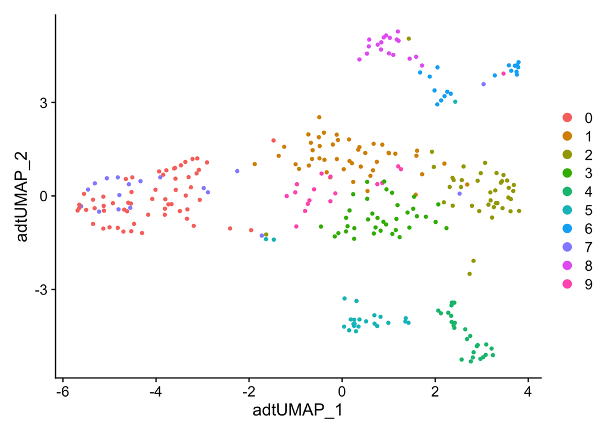

```r
data <- FindClusters(data, graph.name = "ADT_snn", resolution = 2, verbose = FALSE)
data <- RunUMAP(data, reduction = 'apca', dims = 1:10,
              reduction.name = 'adt.umap', reduction.key = 'adtUMAP_')
DimPlot(data, reduction = 'adt.umap')
```

### Multimodal clustering of all cells

```r
data <- FindMultiModalNeighbors(
  data, reduction.list = list("pca", "apca"),
  dims.list = list(1:20, 1:10), modality.weight.name = "RNA.weight"
)
```

```
## Calculating cell-specific modality weights
```

```
## Finding 20 nearest neighbors for each modality.
```

```
## Calculating kernel bandwidths
```

```
## Finding multimodal neighbors
```

```
## Constructing multimodal KNN graph
```

```
## Constructing multimodal SNN graph
```

```r
data <- RunUMAP(data, nn.name = "weighted.nn", reduction.name = "wnn.umap", reduction.key = "wnnUMAP_")
```

```r
data <- FindClusters(data, graph.name = "wsnn", algorithm = 3, resolution = 2, verbose = FALSE)
```

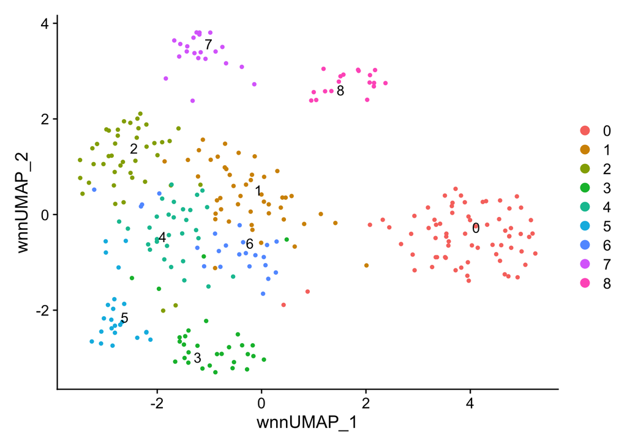

```r
DimPlot(data, reduction = 'wnn.umap', label = TRUE, repel = TRUE)
```

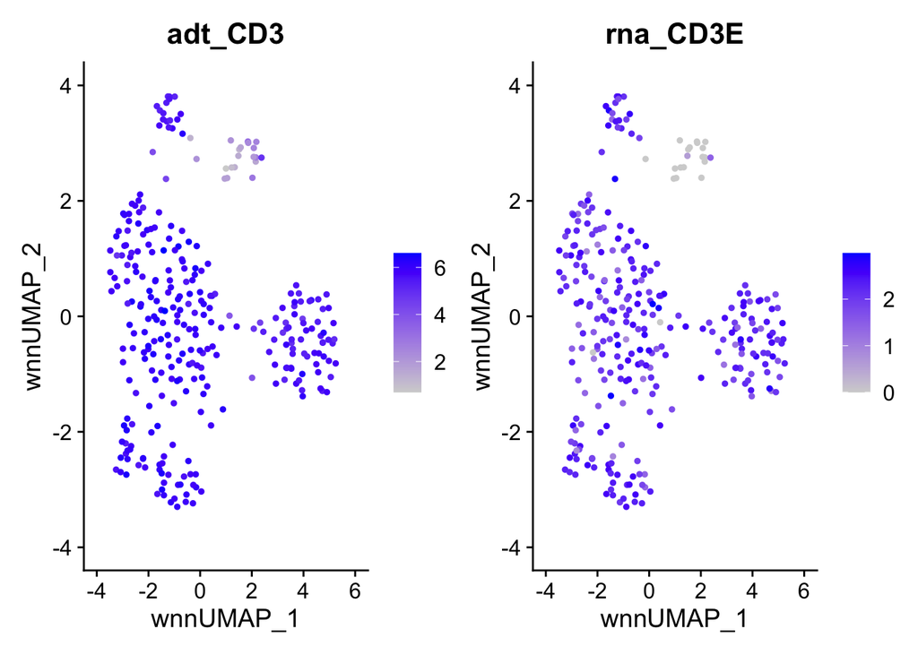

```r
FeaturePlot(data, features = c("adt_CD3","rna_CD3E"), reduction = 'wnn.umap')
```

## Analysis of T-cell subset

### Subset to T-cells

```r
data.tcell <- subset(data, seurat_clusters %in% 0:7)
```

### RNA only clustering of T-cells

```r
DefaultAssay(data.tcell) <- 'RNA'
data.tcell <- NormalizeData(data.tcell) %>% FindVariableFeatures() %>% ScaleData() %>% RunPCA(reduction.name = "pca.tcell")
```

```
## PC_ 1
## Positive:  MYO1F, CST7, S100A4, B2M, GZMA, ANXA2, CYTOR, MIAT, ITGB1, AHNAK
##     NKG7, ACTN4, CCL5, PREX1, CLIC1, HLA-DRB1, SH3BGRL3, FCGR3A, KLRD1, JAKMIP1
##     CCL4, FLNA, GZMB, KLRG1, CYBA, RHOC, SRGN, PYHIN1, PFN1, RAP1GAP2
## Negative:  RPS12, EEF1A1, TPT1, RPS6, LEF1, RPL23, AIF1, FHIT, RPS29, ACTN1
##     LRRN3, RPL36A, SSBP2, FAM153CP, RPS2, IL7R, RPS18, CD7, MAL, MALAT1
##     PRKCQ-AS1, SOCS3, CD55, CHRM3-AS2, ZFP14, HSBP1L1, PLEKHA1, CAMK4, PRKCA, PECAM1
## PC_ 2
## Positive:  KLRD1, GZMB, CCL4, NKG7, CCL5, FCGR3A, SPON2, HOPX, FGFBP2, GZMA
##     CEBPD, GNLY, KLRF1, XCL2, FGR, KLRK1, CXXC5, KLRG1, DGKQ, CD160
##     LAIR1, CCL4L2, GZMH, MATK, CST7, TTC38, FCRL6, EOMES, TRGC2, ACTN4
## Negative:  RPLP0, LTB, RPS29, RPS2, RPLP1, TMSB4X, RPS6, RPS12, RPL23, EEF1A1
##     TMSB10, COTL1, TPT1, AQP3, RPL36A, GAPDH, MAF, GSTK1, LMNA, ARPC1B
##     CCR6, VIM, NPDC1, ITGB1, BIRC3, CRIP1, OPTN, FAS, ADAM19, ANXA1
## PC_ 3
## Positive:  ID1, FAM43A, PLCG2, AC024257.3, NSUN3, BHLHE40, DUSP6, AC092428.1, LPP, RRNAD1
##     GALNT10, SLC12A7, AIFM2, ZNF90, TRPM7, AC025171.3, RNF168, RB1, RGS2, MZF1-AS1
##     DGKQ, GNLY, FGR, ZFC3H1, LINC00476, CEBPD, CASP8AP2, SPEN, UTRN, ACTN4
## Negative:  RPS12, RPS2, RPS6, RPLP1, TMSB4X, EEF1A1, TMSB10, RPL36A, RPS29, ACTB
##     ACTG1, CFL1, FCGR3A, PFN1, CTSW, MT-CO3, HLA-A, RPLP0, FGFBP2, B2M
##     KLRK1, KLRG1, GZMA, KLRF1, TRGC2, HCST, CST7, CD8A, XCL2, GZMH
## PC_ 4
## Positive:  JUNB, DUSP1, FOS, ZFP36, JUN, DUSP2, NFKBIA, IER2, NR4A2, CD69
##     BTG2, SERTAD1, KLF2, TUBA1A, ANXA1, ZFP36L2, H3F3B, TSC22D3, CXCR4, FOSB
##     IER5, MYADM, INTS6, PPP1R15A, HMGCS1, ZNF331, UBE2S, DNAJB1, MIDN, RGCC
## Negative:  MALAT1, AC004687.1, SHPRH, ATRX, RASGRP1, TXNIP, RIPOR2, NUP50-DT, ACSL3, LUC7L3
##     RPL23, CEP63, KANSL1, LINC00342, PCSK7, LRRN3, ANKRD36C, MED15, NUTM2A-AS1, MACF1
##     BCL2, SMC5, CELF1, RNF220, TRIM56, CEP350, LINC01176, FYB1, OGT, SAMD3
## PC_ 5
## Positive:  EOMES, CCL4L2, GZMH, FCRL6, TTC38, IFNG, ST8SIA6, JAKMIP1, AL035701.1, HLA-DRB1
##     ZNF574, LAIR2, RAP1GAP2, PATL2, POMC, ZNF518A, MIAT, CACNA2D4, ASCL2, GSE1
##     TNF, TRGC2, NIPSNAP3A, SLC35E3, AL163051.1, ADAM15, HCG25, CYTOR, NFAT5, LAIR1
## Negative:  TRGC1, KLRC4, LINC002481, CEBPD, AP001816.1, CLIC3, RAB27B, ERICH6-AS1, HARS2, FCER1G
##     FCRLB, EFHD2, GNLY, TYROBP, KLRB1, USP13, ANO10, ZNF736, CD160, HOPX
##     KLB, YES1, C1RL, PMAIP1, PRR5, GPR65, AC253572.2, NCR3, APOBEC3G, HEATR6
```

```r
data.tcell <- FindNeighbors(data.tcell, reduction = "pca.tcell", dims = 1:10)
data.tcell <- FindClusters(data.tcell, resolution = 2, verbose = FALSE)
data.tcell <- RunUMAP(data.tcell, reduction = 'pca.tcell', dims = 1:10, assay = 'RNA',
              reduction.name = 'rna.tcell.umap', reduction.key = 'rnaTcellUMAP_')
```

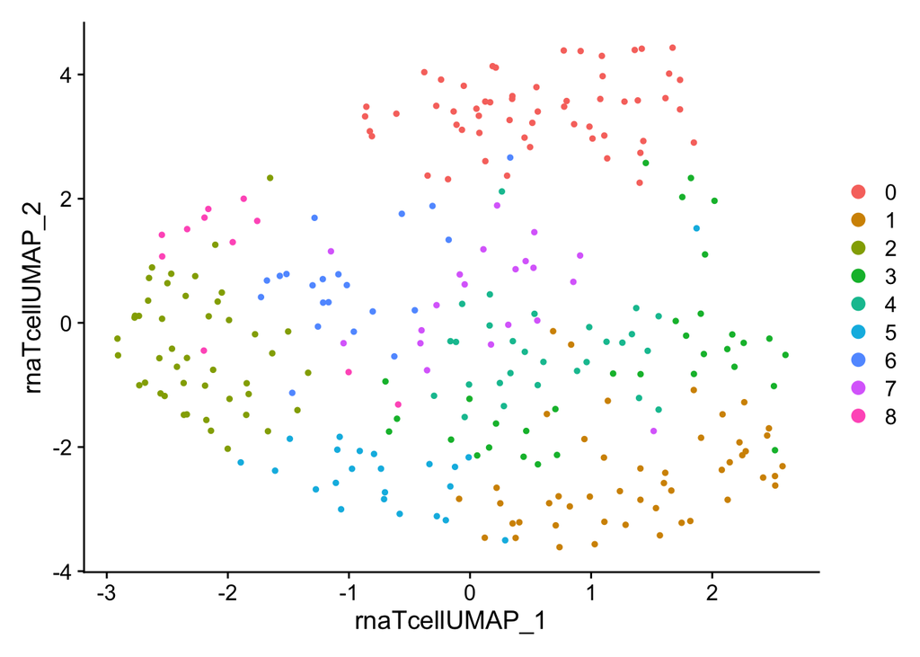

```r
DimPlot(data.tcell, reduction = 'rna.tcell.umap')
```

### ADT only clustering of T-cells

```r
DefaultAssay(data.tcell) <- 'ADT'
VariableFeatures(data.tcell) <- rownames(data.tcell[["ADT"]])
data.tcell <- NormalizeData(data.tcell, normalization.method = 'CLR', margin = 2) %>%
  ScaleData() %>% RunPCA(reduction.name = 'apca.tcell', dims = 1:10)
```

```
## Normalizing across cells
```

```
## PC_ 1
## Positive:  CD45RA, CD8a, CD34.1, CD56, CD16, CD274.1, IgG2a, CD15, CD20, CD14.1
##     IgG2b, CD19.1
## Negative:  CD45RO, CD25, CD4.1, PD-1, TIGIT.1, CD127, CD62L, CD80.1, IgG1, CD86.1
##     CD3, CD28.1
## PC_ 2
## Positive:  TIGIT.1, CD16, CD56, CD8a, CD25, CD45RO, PD-1, CD14.1, CD80.1, CD274.1
##     CD62L, CD86.1
## Negative:  CD3, CD4.1, CD127, CD19.1, CD45RA, CD20, CD28.1, IgG2b, IgG1, CD34.1
##     IgG2a, CD15
## PC_ 3
## Positive:  CD15, CD56, CD4.1, CD16, IgG2a, CD19.1, PD-1, CD20, CD45RA, CD274.1
##     IgG1, TIGIT.1
## Negative:  CD8a, CD127, IgG2b, CD34.1, CD45RO, CD86.1, CD62L, CD80.1, CD28.1, CD3
##     CD25, CD14.1
## PC_ 4
## Positive:  IgG2b, CD28.1, CD274.1, CD62L, CD127, IgG1, CD16, CD15, CD14.1, CD56
##     CD20, CD19.1
## Negative:  IgG2a, CD34.1, PD-1, TIGIT.1, CD3, CD4.1, CD45RA, CD80.1, CD86.1, CD8a
##     CD45RO, CD25
## PC_ 5
## Positive:  CD14.1, CD19.1, IgG1, CD15, CD8a, CD45RO, CD3, CD127, CD25, PD-1
##     CD16, IgG2a
## Negative:  CD20, CD274.1, TIGIT.1, CD86.1, CD4.1, IgG2b, CD45RA, CD28.1, CD62L, CD80.1
##     CD34.1, CD56
```

```r
data.tcell <- RunUMAP(data.tcell, reduction = 'apca.tcell', dims = 1:10, assay = 'ADT',
              reduction.name = 'adt.tcell.umap', reduction.key = 'adtTcellUMAP_')
data.tcell <- FindNeighbors(data.tcell, reduction = "apca.tcell", dims = 1:10)
```

```r
data.tcell <- FindClusters(data.tcell, graph.name = "ADT_snn", resolution = 2, verbose = FALSE)
data.tcell <- FindClusters(data.tcell, algorithm = 3, resolution = 2, verbose = FALSE)
```

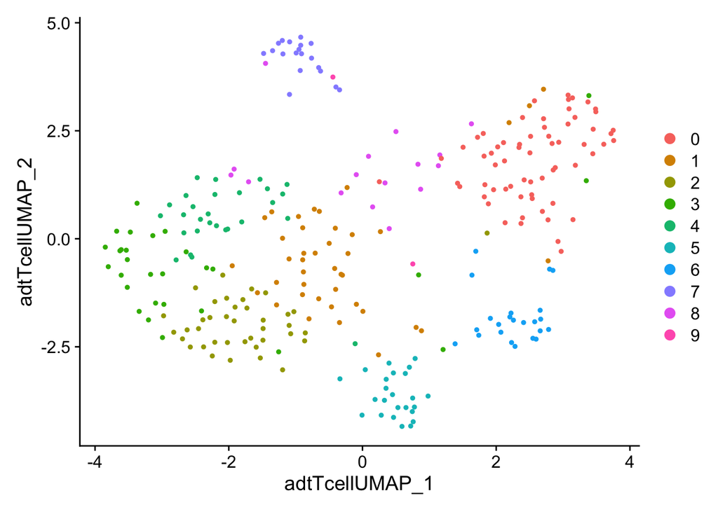

```r
DimPlot(data.tcell, reduction = 'adt.tcell.umap')
```

### Multimodal clustering of T-cells

```r
data.tcell <- FindMultiModalNeighbors(
  data.tcell, reduction.list = list("pca.tcell", "apca.tcell"),
  dims.list = list(1:10, 1:10), modality.weight.name = "RNA.weight"
)
```

```
## Calculating cell-specific modality weights
```

```
## Finding 20 nearest neighbors for each modality.
```

```
## Calculating kernel bandwidths
```

```
## Finding multimodal neighbors
```

```
## Constructing multimodal KNN graph
```

```
## Constructing multimodal SNN graph
```

```r
data.tcell <- RunUMAP(data.tcell, nn.name = "weighted.nn", reduction.name = "wnn.tcell.umap", reduction.key = "wnnTcellUMAP_")
```

```r
data.tcell <- FindClusters(data.tcell, graph.name = "wsnn", algorithm = 3, resolution = 2, verbose = FALSE)
```

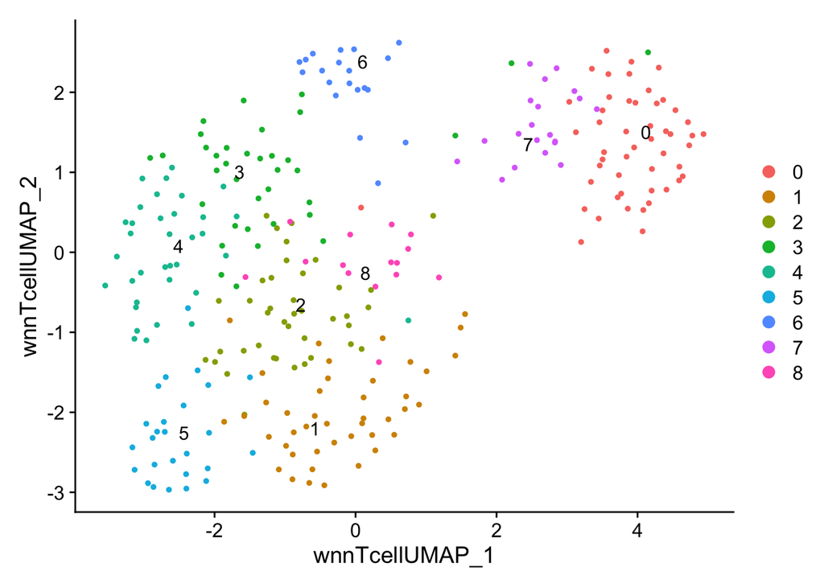

```r
DimPlot(data.tcell, reduction = 'wnn.tcell.umap', label = TRUE, repel = TRUE)
```

The data matrices stored within a Seurat object will be saved to an “rds” file. Note that we could extract and save each matrix in a basic txt or mtx file as well.

```r
saveRDS(data.raw, "pbmc1k_seurat_raw.rds")
saveRDS(data.nonempty, "pbmc1k_seurat_nonempty.rds")
saveRDS(data, "pbmc1k_seurat_filtered.rds")
saveRDS(data.tcell, "pbmc1k_seurat_tcell.rds")
```